# Копула

Doynikov A

January 14, 2019

При исследовании временных рядов часто возникает задача исследования формы зависимости между рядами наблюдений. Знание формы зависимости необходимо учитывать при их моделировании и прогнозировании.  
При исследовании зависимости первое, что приходит на ум это вычислить коэффициент корреляции.

`Определение`. Для двух случайных величин $X$ и $Y$ коэффициентом корреляции Пирсона называется число $\rho(X,Y)$
$$\rho(X,Y) = \frac{cov(X,Y)}{\sqrt{D(X)D(Y)}}=\frac{E(X-EX)(Y-EY}{{\sqrt{D(X)D(Y)}}}$$
Здесь как и везде символами $E(X),D(X)$ обозначается математическое ожидание и дисперсия случайной величины $X$ соответственно. Основные свойства коэффициента корреляции хорошо известны:

1. Пусть $X,Y$ независимые случайные величины,тогда $\rho(X,Y)=0$
2. Пусть $\rho(X,Y)=+-1$ тогда существуют числа $a$ и $b$ такие, что
   $$Y = aX+b$$

Отметим и недостаки коэффициента корреляции Пирсона при исследовании завичимости.

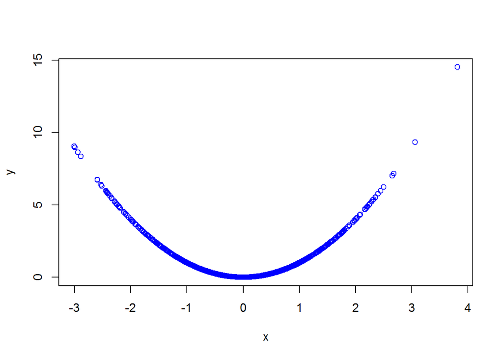

```r
    n <- 1000
    set.seed(1)
    x <- rnorm(n)
    y <- x^2
    plot(x,y,type = "p",pch = 21,col = "blue")
```

```r
    cor(x,y)
```

```
## [1] -0.02948134
```

Следующий недостаток это то, что для вычисления корреляции необходимо чтобы $D(X),D(Y) < \infty$ дисперсии были конечны, что совсем не всегда. У распределений с так называемыми “толстыми хвостами” дисперсия может быть и бесконечна. Как в этом случае исследовать зависимость?

Для нормально распределенных случайных величин некоррелируемость $\rho(X,Y)=0$ влечет независимость. Для любых других это, вообще говоря, неверно.

На практике часто приходится преобразовывать данные с помощью даже “хороших” монотонных преобразований, но здесь нас ожидает еще один недостаток корреляции.
$$\rho(X,Y) \ne \rho(\ln X,\ln Y)$$

```r
ax <- abs(x)
cor(ax,y)
```

```
## [1] 0.9391225
```

```r
cor(log(ax),log(y))
```

```
## [1] 1
```

Хотя логарифм является и “хорошим” монотонным преобразованием.

Мощным средсвом для реального исследования зависимости является аппарат копул (лат. Copula — соединение, связка).

Как и выше определения будем давать для двух случайных величин, но все без труда переносится для любой большей размерности.

Определение. Копула — это многомерная функция распределения, определённая на $n$-мерном единичном кубе такая, что каждое её маргинальное распределение равномерно на отрезке $[0,1]$.

Пусть сл.в. $X$ имеет распределение $F_X$ , а сл.в. $Y$ соответственно $F_Y$ а $F_XY$ их совместное распределение. Хорошо известно свойство, что распределение сл.в. $F_X(X)= U_X,F_Y(Y)=U_Y$ будут равномерными на отрезке $[0,1]$. Двумерная непрерывная функция $с(u_X,u_Y)$ такая, что для любых $u_X,u_Y \in [0,1]$
$$с(u_X,u_Y)= P[F_X(X)< u_X,F_Y(Y)<u_Y]$$
Это и есть КОПУЛА.

Построение копул для описания многомерного со- вместного распределения основано на выводах теоремы Шкляра (1959).

Теорема Шкляра. Пусть F – совместная функция распределения двух случайных величин X, Y, которые имеют частные функции распределения U и G соответственно. Тогда существует такая копула C, что для любых x, y можно записать:
$$F(x,y)= C(U(x),G(y))$$

## Эмпирическая копула

Пусть имеются $n$ наблюдений над двумерной случайной величиной $(X,Y)$
$$(x_1,y_1),(x_2,y_2),..,(x_n,y_n)$$
для каждой их компонент построим последовательности рангов - порядковые номера каждого наблюдения компоненты в упорядоченных последовательностях
$$x_{(1)}<=x_{(2)}<=....<=x_{(n)}$$
$$y_{(1)}<=y_{(2)}<=....<=y_{(n)}$$
Поделим ранги на количество переменных выборки Таким образом нормированные ранги изобразим в виде X-Y графика это и есть эмпирическая копула. Любое монотонное преобразование данных не изменит рангов наблюдений, а следовательно не изменит и вида эмпирической копулы. Напомним у корреляции такого свойство нет.

### Построение эмпирической копулы для доходностей курса рубля и цен на нефть

```r
dat <- read.csv('./RubleRates.csv',sep = ",")
head(dat)
```

```
##          X318x6      Rub.Usd        brent        sp500      GAZPROM
## 1 1/11/16 12:00 -0.005162439  0.009705793  0.006734183  0.001774754
## 2 1/11/16 13:00 -0.002184241  0.005407029 -0.003577910 -0.002952683
## 3 1/11/16 14:00  0.001061344 -0.008066926 -0.002706078 -0.004145998
## 4 1/11/16 15:00 -0.001162265  0.001807229  0.002400334 -0.002155974
## 5 1/11/16 16:00 -0.001411732 -0.000300661 -0.001561687  0.001043064
## 6 1/11/16 17:00  0.003057320  0.001203008  0.003076121  0.000893123
##           Gold       EUR.USD
## 1 -0.005335021 -0.0015779090
## 2 -0.000727273  0.0001286370
## 3  0.004002911  0.0014607660
## 4 -0.000906125 -0.0001743020
## 5  0.000544168 -0.0000367016
## 6 -0.002356780 -0.0015874040
```

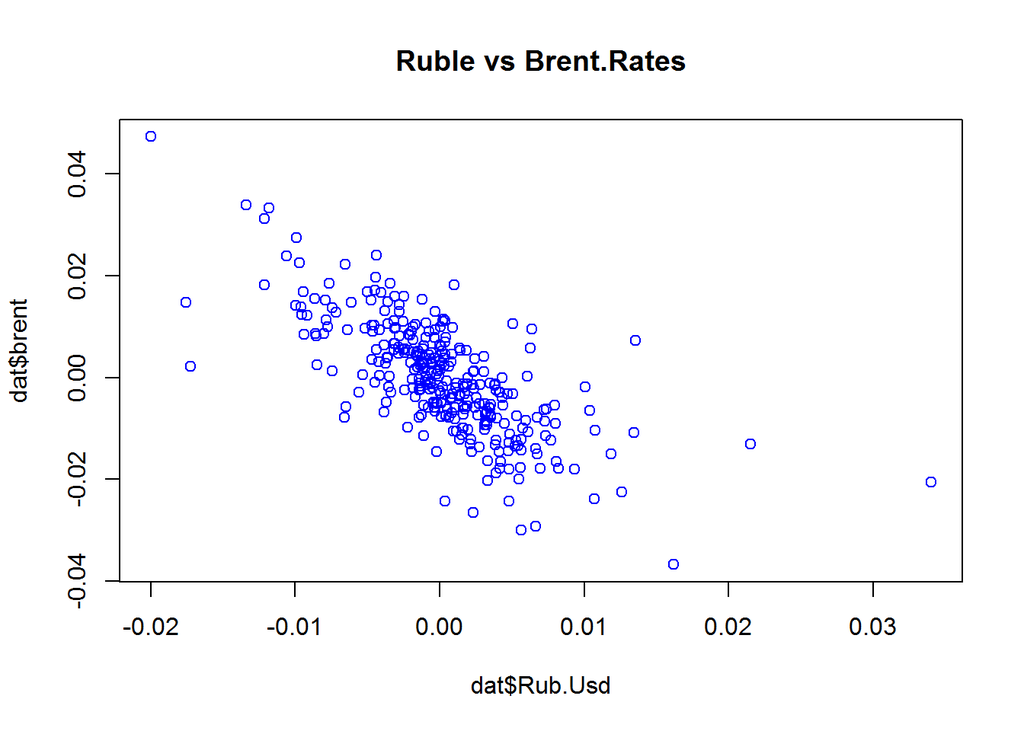

```r
plot(dat$Rub.Usd,dat$brent,pch = 21,main ="Ruble vs Brent.Rates",col = "blue")
```

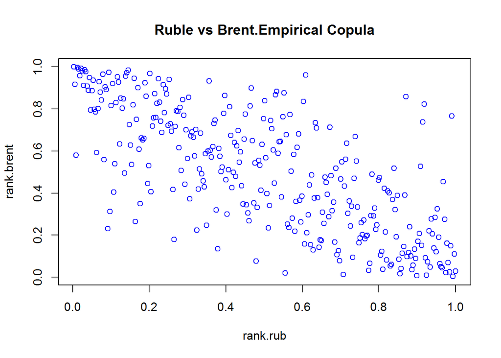

```r
rank.rub <- rank(dat$Rub.Usd)/length(dat$Rub.Usd)
rank.brent <- rank(dat$brent)/length(dat$Rub.Usd)
plot(rank.rub, rank.brent,  pch = 21,main ="Ruble vs Brent.Empirical Copula",col = "blue")
```

В языке R присутсвует функция pobs() из library(copula), которая практически и готовит данные для эмпирической копулы. Сравните график с предыдущим

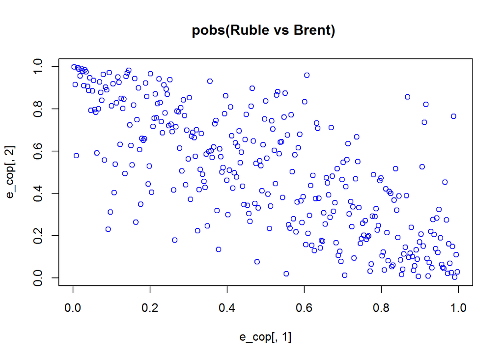

```r
library(copula)
ruble_brent <- cbind(dat$Rub.Usd,dat$brent)
e_cop <-pobs(ruble_brent)
plot(e_cop[,1],e_cop[,2],pch = 21,main ="pobs(Ruble vs Brent) ",col = "blue")
```

## Параметрические модели копул

Выделяют несколько основных семейств копул: эллипсообраз- ные, архимедовы, экстремальные. Прежде чем перейти к рассмотре- нию отдельных семейств копул, введем понятие независимой копылы. Независимая копула соответствует случаю, когда все случайные величины, входящие в нее независимы
$$C(u_1,u_2)= u_1u_2$$
здесь $u_i$ - обратная к функции распределения случайной величины с номером $i$. Выделяют Эллипсоидальные копулы (Гауссовская,Стьюдента), Архимедовы (Франка, Клейтона) и другие семейства копул.

### Гауссовская копула

Пусть $\Phi(x)$ функция распределения стандартной нормальной случайной величины а $\Phi^{-1}(u)$ обратная к ней. Двумерная случайная величина $(X_1,X_2)$ имеет двумерное нормальное распределение плотность которого
$$F(x_1,x_2)= \frac{1}{2\pi\sigma_1\sigma_2sqrt{(1-\rho^2)}}
e^{-\frac{z}{2(1-\rho^2)}}$$
где
$$z = \frac{(x_1-\mu_1)^2}{\sigma_1^2}+\frac{(x_2-\mu_2)^2}{\sigma_2^2}-
\frac{2\rho(x_1-\mu_1)(x_2-\rho_2)}{\sigma_1\sigma_2}$$
Понятно,что каждое частное распределение будет нормальным $N(\mu_1,\sigma_1^2),N(\mu_2,\sigma_2^2)$ соответственно. Функция
$$C (u_1, u_2) = F(\Phi^{-1}(u_1),\Phi^{-1}(u_2))$$
называется Гауссовской или Нормальной копулой.

Пусть параметр Гауссовской копулы $\rho = 0.9$

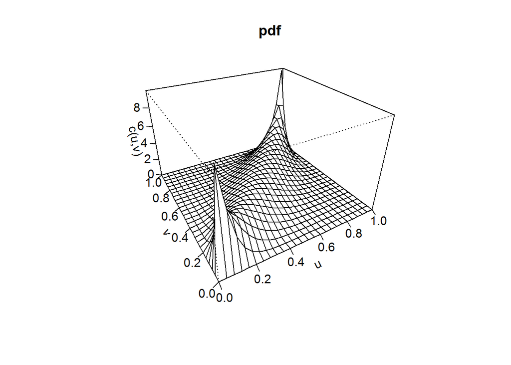

```r
Gaussian.Copula.0.9<-normalCopula(param=.9,dim=2)
persp(Gaussian.Copula.0.9, dCopula, main="pdf",xlab="u", ylab="v", zlab="c(u,v)")
```

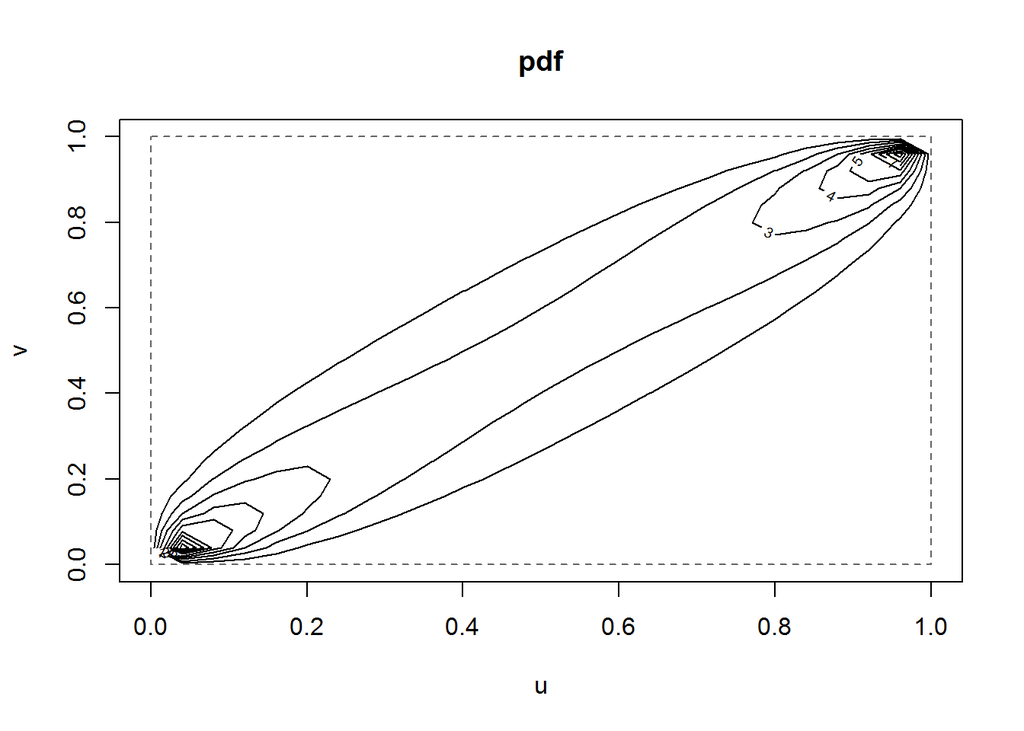

```r
contour(Gaussian.Copula.0.9,dCopula, main="pdf",xlab="u", ylab="v")
```

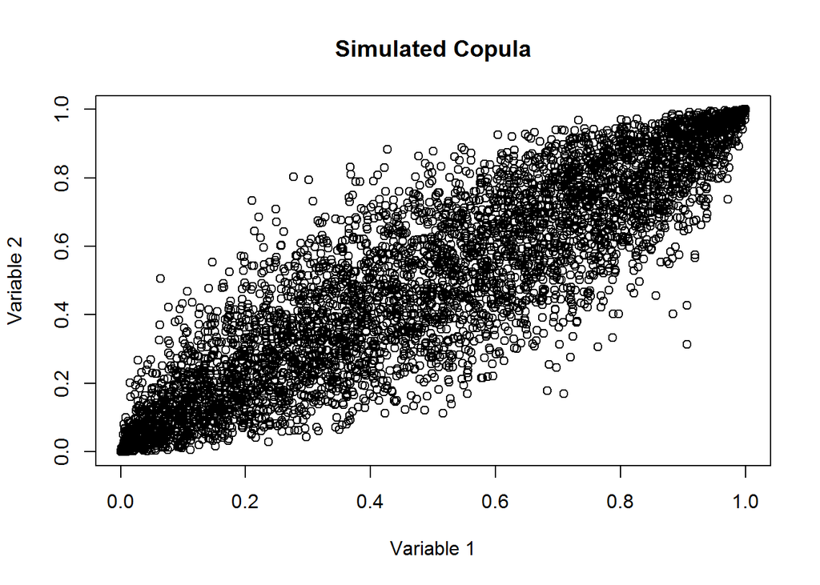

```r
Simulated.Gaussian.Copula<-rCopula(5000,Gaussian.Copula.0.9)
SimulatedN<-length(Simulated.Gaussian.Copula[,1])
plot(Simulated.Gaussian.Copula,main="Simulated Copula",xlab="Variable 1",ylab="Variable 2")
```

В первой переменной сделаем частное распределение гамма

```r
      SimulatedDistr <- Simulated.Gaussian.Copula
      SimulatedDistr[,1]<-qgamma(Simulated.Gaussian.Copula[,1],1,2)
```

Вторую оставим нормальной но дисперсию сделаем равной 4.

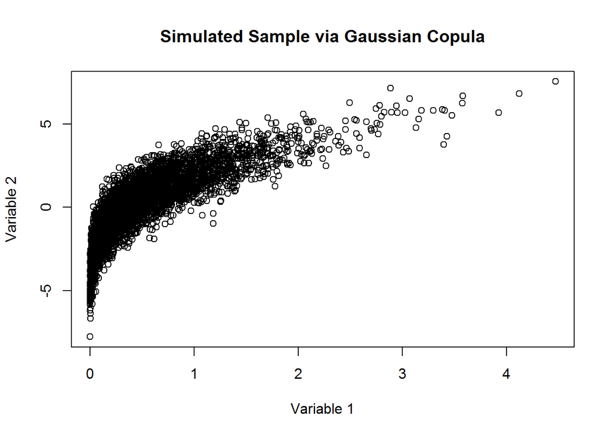

```r
      SimulatedDistr[,2]<-qnorm(Simulated.Gaussian.Copula[,2],0,2)

    plot(SimulatedDistr, main="Simulated Sample via Gaussian Copula",xlab="Variable 1",ylab="Variable 2")
```

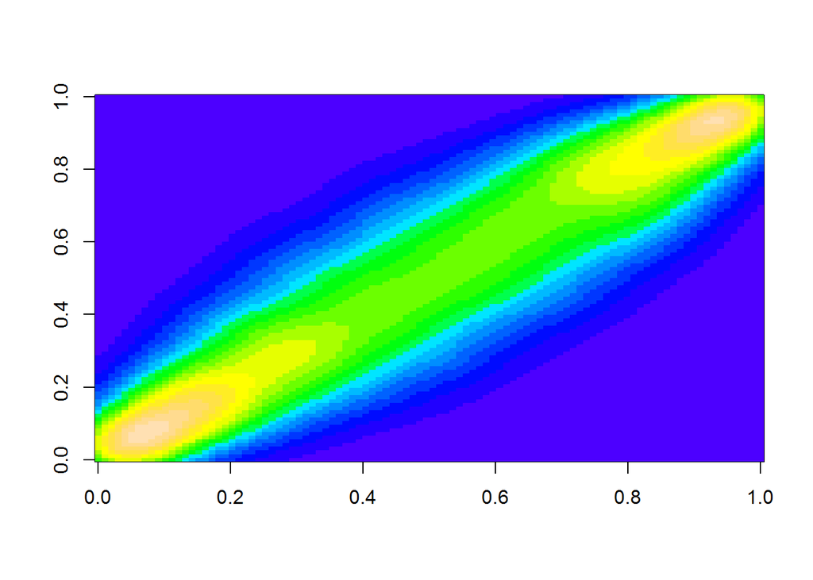

```r
library(MASS)
k <- kde2d(rank(SimulatedDistr[,1])/SimulatedN,
           rank(SimulatedDistr[,2])/SimulatedN, n=100)
image(k,col=topo.colors(20))
```

Теперь попробуем оценинть Гауссовскую копулу по данным Рубль-Брент. Мы подготовили уже для них эмпирическую копулу с помощью функции pobs(). Сначала посмотрим на выборочную гистограмму. Я не нашел соответствуюшего метода в R. Поэтому написал оценку гистограммы для двумерной выборки самостоятельно.

```r
library(latticeExtra)
```

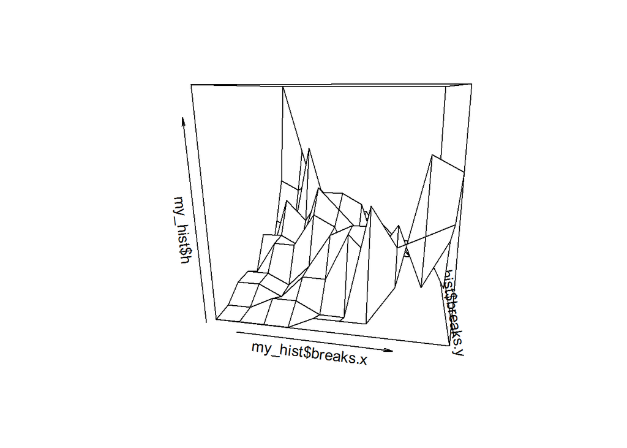

```r
  my_hist3d <- function(x, y, freq, nclass="auto") {
  n<-length(x)
  if (nclass == "auto") { nclass<-ceiling(sqrt(nclass.Sturges(x))) }
  breaks.x <- seq(min(x),max(x),length=(nclass+1))
  breaks.y <- seq(min(y),max(y),length=(nclass+1))
  h <- NULL
  for (i in 1:nclass)
    for (j in 1:nclass)
      h <- c(h, sum(x <= breaks.x[j+1] & x >= breaks.x[j] & y <= breaks.y[i+1] & y >= breaks.y[i] ) )
  dim(h) <- c(nclass,nclass)
  return (list(breaks.x = breaks.x[-1],breaks.y= breaks.y[-1],h = h))
}
 my_hist <- my_hist3d(e_cop[,1],e_cop[,2], freq=FALSE,nclass = 10)


persp(my_hist$breaks.x,my_hist$breaks.y,my_hist$h,theta = 10)
```

```r
   Gaussian.Copula.Object<-normalCopula(param=-0.7,dim=2)
   Gaussian.Copula.fit<-fitCopula(Gaussian.Copula.Object,
                               e_cop,
                               method = "ml",
                               optim.method = "BFGS",
                               optim.control = list(maxit=1000))
   parameters <- Gaussian.Copula.fit@copula@parameters
   parameters
```

```
## [1] -0.7457961
```

Как и следовало ожидать параметр $\rho$ отрицательный. Нарисуем ее.

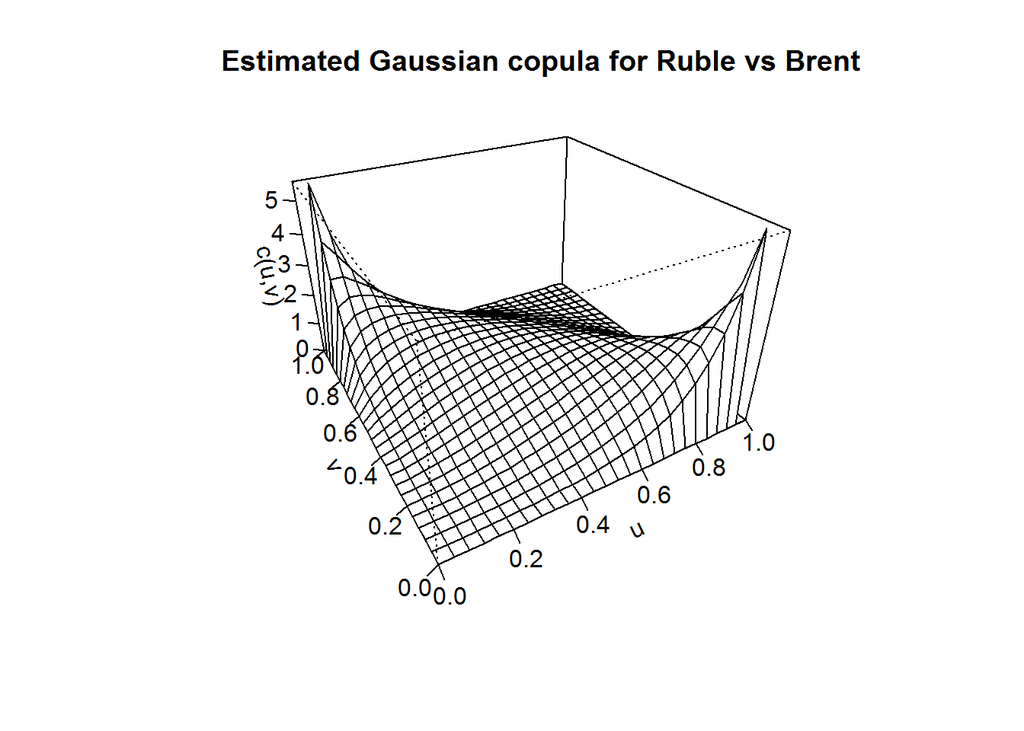

```r
Gaussian.Copula.Object@parameters<-parameters
persp(Gaussian.Copula.Object, dCopula, main="Estimated Gaussian copula for Ruble vs Brent",xlab="u", ylab="v", zlab="c(u,v)")
```

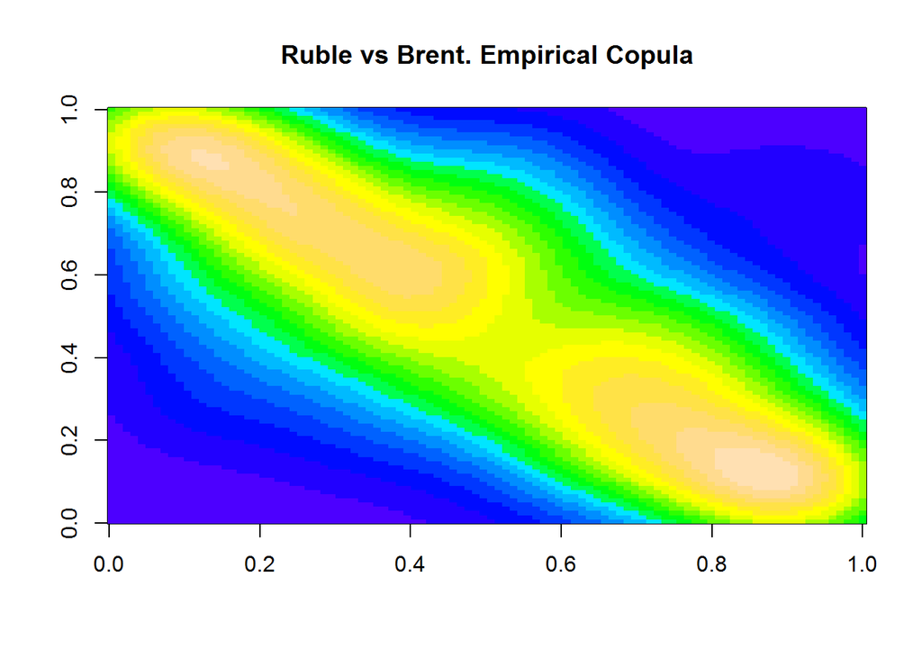

```r
rank.rub <- rank(dat$Rub.Usd)/length(dat$Rub.Usd)
rank.brent <- rank(dat$brent)/length(dat$Rub.Usd)

kbrent <- kde2d(rank.rub,
           rank.brent, n=100)
image(kbrent,main = "Ruble vs Brent. Empirical Copula",col=topo.colors(20))
```

К недостатку Гауссовских копул можно отнести недостаточно хорошее оценку зависимости на хвостах. Для финансовых временных рядов это имеет очень важное значение при оценке рисков.

### Копула Стьюдента

Некоторых недостатков Гауссовской копулы, в частности, недостаточно хорошей оценке зависимости на хвостах,нет в копуле Стьдента или Т копуле.

Для T копула-функции справедливо соотношение:
$$C^{t-copula}(u_1,u_2,\rho,\nu)=T^2(t_{\nu}^{-1}(u_1),t_{\nu}^{-1}(u_2),\rho,\nu)$$
где $T^2(t_{\nu}^{-1}(u_1),t_{\nu}^{-1}(u_2),\rho,\nu)$ функция распределения двумерного распределения Стьюдента с корреляцией $\rho$ и $\nu$ степенями свободы. $t_{\nu}^{-1}()$ обратная функция одномерного распределения Стьюдента c $\nu$ степенями свободы.

При $\nu->\infty$ копула-функция Стьюдента сходится к нормальной копула-функции, а при $\nu->1$ сходится к копула-функции распределения Коши.

Оценим t-копулу к нашим данным рубль-брент

```r
student.cop <- ellipCopula(family = 't',dim = 2,df = 4,df.fixed= FALSE)
t.Copula.fit<-fitCopula(student.cop,
                               e_cop,
                               method = "ml",
                               optim.method = "BFGS",
                               optim.control = list(maxit=1000))
parameters <- t.Copula.fit@copula@parameters
parameters
```

```
## [1] -0.7532619  5.9154939
## attr(,"fixed")
## [1] FALSE FALSE
```

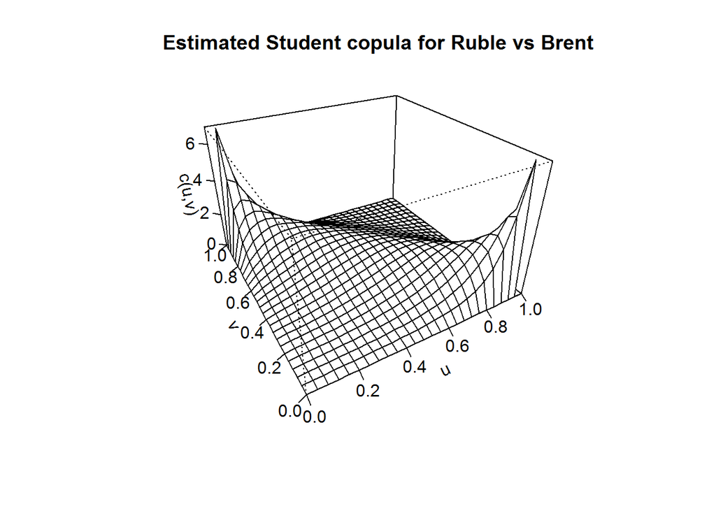

```r
student.cop@parameters <- parameters
persp(student.cop, dCopula, main="Estimated Student copula for Ruble vs Brent",xlab="u", ylab="v", zlab="c(u,v)")
```

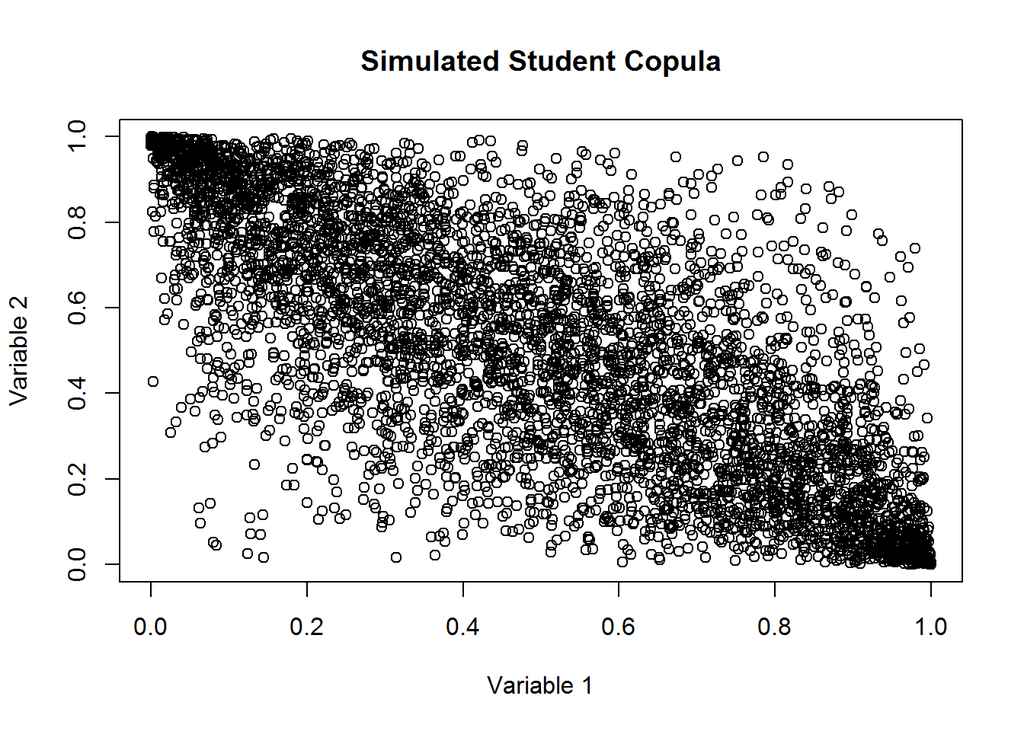

```r
Simulated.studentCopula<-rCopula(5000,student.cop)
SimulatedN<-length(Simulated.studentCopula[,1])
plot(Simulated.studentCopula,main="Simulated Student Copula",xlab="Variable 1",ylab="Variable 2")
```

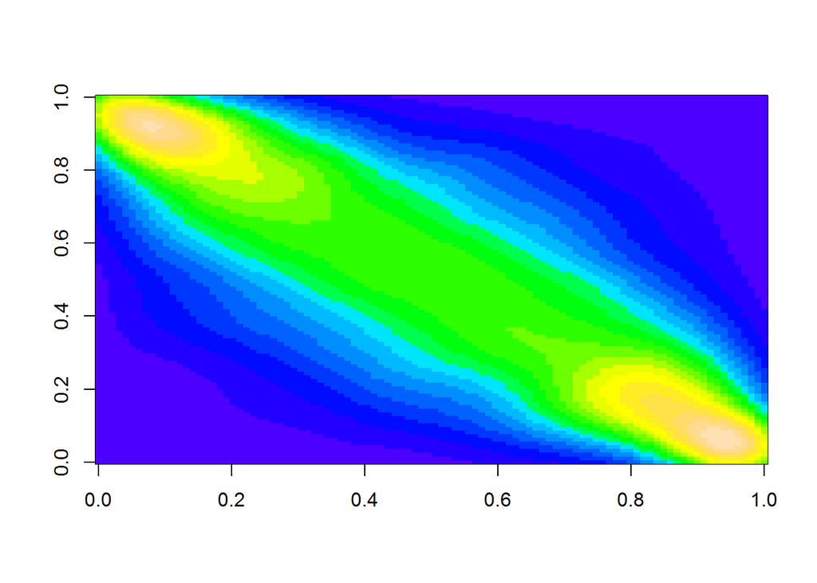

```r
k <- kde2d(rank(Simulated.studentCopula[,1])/SimulatedN,
           rank(Simulated.studentCopula[,2])/SimulatedN, n=100)
image(k,col=topo.colors(20))
```

## Архимедовы копулы

Копулы вида
$$c(x,y)= \Psi(\Psi^{-1}(x)+\Psi^{-1}(y))$$
где фунция $\Psi()$ произвольная функция,удовлетворяющая условиям
$$\Psi(1)= 0,\lim_{x->0}\Psi(x)= \infty, \Psi'(x)<=0,\Psi''(x)>0$$

Функцию $\Psi(x)$ называют функциями генераторами.

### Копула Клейтона(Clayton)

Пусть функции генаратор имеет следующий вид:
$$\Psi(x) = x^{\theta}-1$$
и $\theta<=0$. Тогда копулой Клейтона называют копулу вида
$$c(x,y)=(x^{\theta}+y^{\theta}-1)^{\frac{1}{\theta}}$$

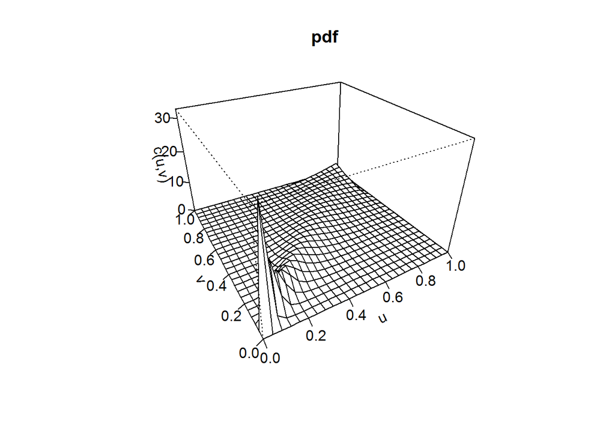

```r
claytonCopula.Object <- claytonCopula(param = 5, dim = 2)
persp(claytonCopula.Object, dCopula, main="pdf",xlab="u", ylab="v", zlab="c(u,v)")
```

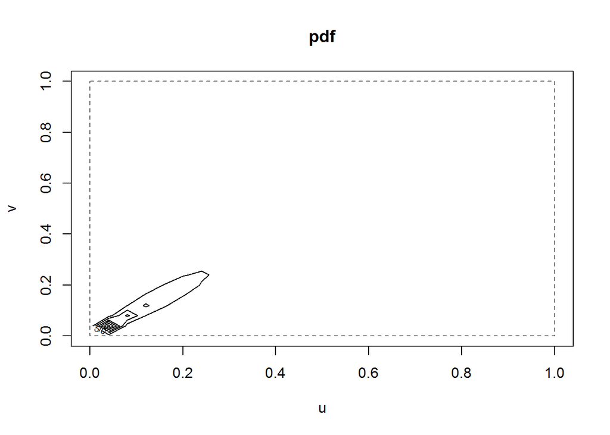

```r
contour(claytonCopula.Object,dCopula, main="pdf",xlab="u", ylab="v")
```

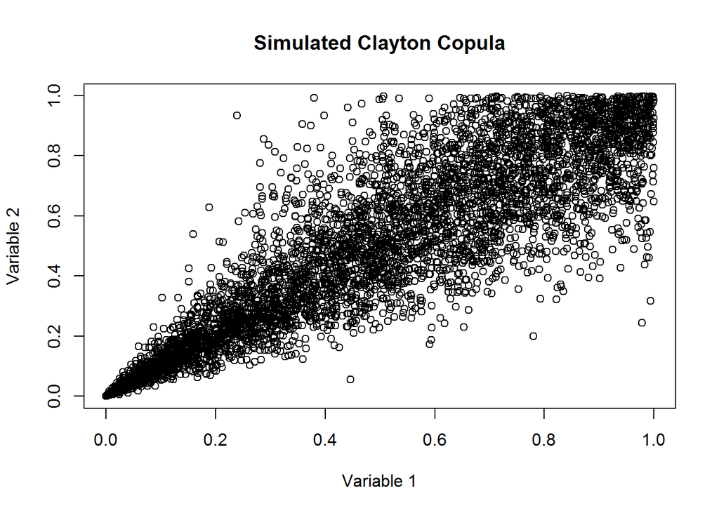

```r
Simulated.claytonCopula<-rCopula(5000,claytonCopula.Object)
SimulatedN<-length(Simulated.claytonCopula[,1])
plot(Simulated.claytonCopula,main="Simulated Clayton Copula",xlab="Variable 1",ylab="Variable 2")
```

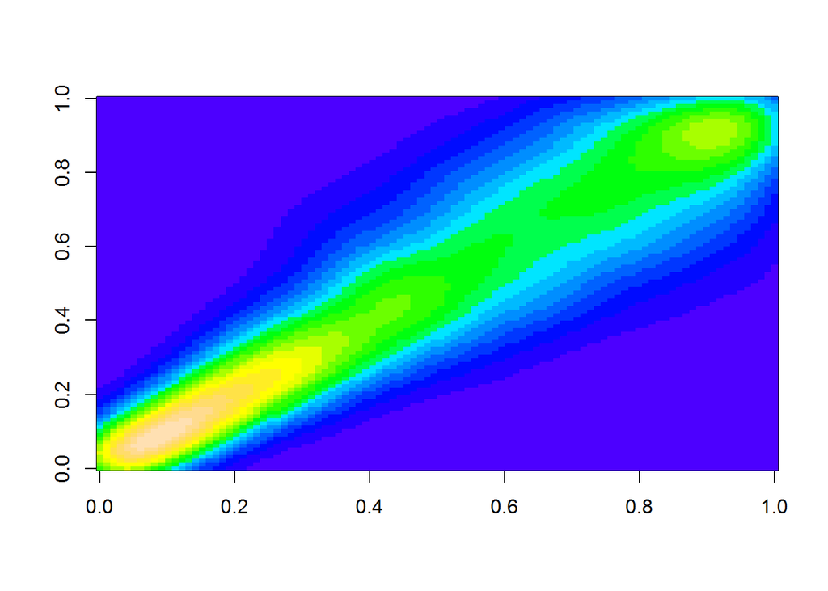

```r
k <- kde2d(rank(Simulated.claytonCopula[,1])/SimulatedN,
           rank(Simulated.claytonCopula[,2])/SimulatedN, n=100)
image(k,col=topo.colors(20))
```

Попробуем оценить копулу Клейтона к нашим данным по рублю и нефти.

```r
   Clayton.Copula.fit<-fitCopula(claytonCopula.Object,
                               e_cop,
                               method = "ml",
                               optim.method = "BFGS",
                               optim.control = list(maxit=1000))
   parameters <- Clayton.Copula.fit@copula@parameters
   parameters
```

```
## [1] -0.3587703
```

### Копула Франка

Другим примером архимедовых копул является копула Франка (Frank) Пусть функция генератора имеет вид
$$\Psi(u) = -\frac{1}{\alpha}\ln(1+e^{\alpha u}(e^{-\alpha}-1))$$
Тогда копулой Франка называют копулу вида:
$$c(x,y)= -\frac{1}{\alpha}\ln[1+\frac{(e^{-\alpha x}-1)(e^{-\alpha y}-1)}{(e^{-\alpha}-1)^{2-1}}]$$

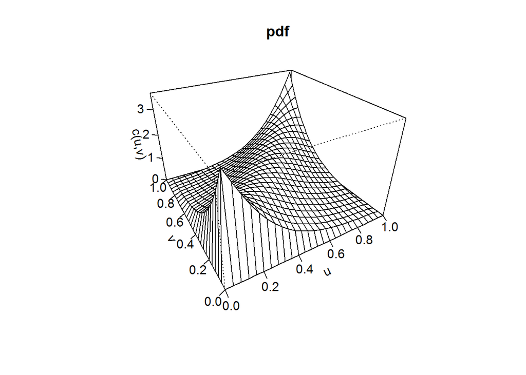

```r
FrankCopula.Object <- frankCopula(param = 5, dim = 2)
persp(FrankCopula.Object, dCopula, main="pdf",xlab="u", ylab="v", zlab="c(u,v)")
```

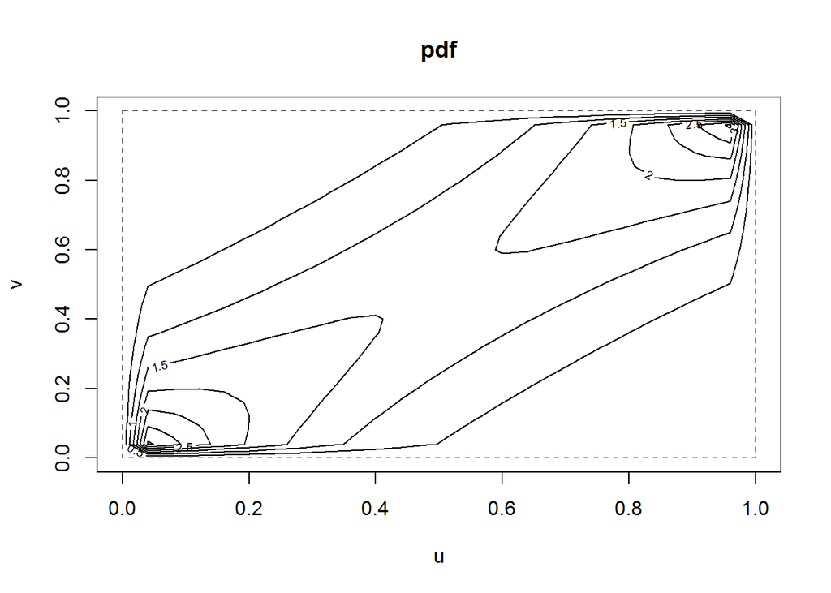

```r
contour(FrankCopula.Object,dCopula, main="pdf",xlab="u", ylab="v")
```

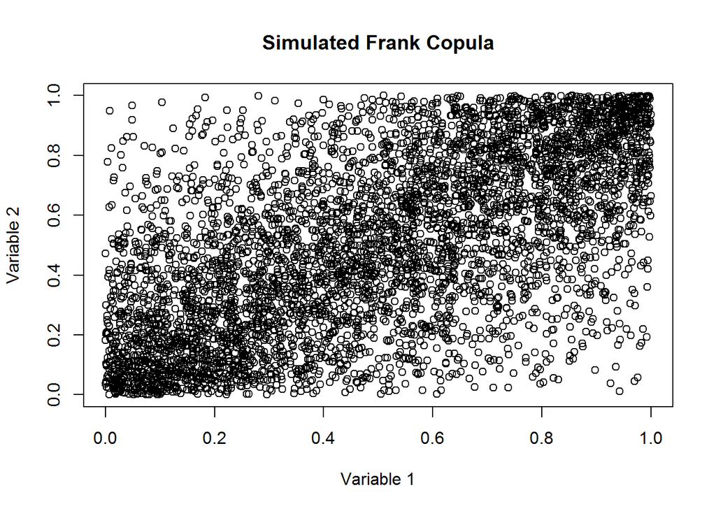

```r
Simulated.FrankCopula<-rCopula(5000,FrankCopula.Object)
SimulatedN<-length(Simulated.FrankCopula[,1])
plot(Simulated.FrankCopula,main="Simulated Frank Copula",xlab="Variable 1",ylab="Variable 2")
```

Попробуем оценить копулу Франка к нашим данным по рублю и нефти.

```r
   Frank.Copula.fit<-fitCopula(FrankCopula.Object,
                               e_cop,
                               method = "ml",
                               optim.method = "BFGS",
                               optim.control = list(maxit=1000))
   parameters <- Frank.Copula.fit@copula@parameters
   parameters
```

```
## [1] -6.73945
```

Существуют и другие примеры архимедовых копул.

итак к нашим данным рубль-брент мы оценили четыре различные копулы. Сравним максимумы функции правдоподобия при каждой из них

```r
t.Copula.fit@loglik
```

```
## [1] 131.0981
```

```r
Gaussian.Copula.fit@loglik
```

```
## [1] 125.2536
```

```r
Frank.Copula.fit@loglik
```

```
## [1] 123.0339
```

```r
Clayton.Copula.fit@loglik
```

```
## [1] 53.36234
```

Лучшей из них к данным рубль-брент подходит t-копула.

## Условное распределение копулы

Пусть задана копула
$$P[X \le x,Y\le y]= C(F_X(x),F_Y(y))= C(u,v)$$
Тогда условные вероятности

$$C_{2|1}(v|u) = P[V\le v,U=u] = \frac{d}{du}C(u,v)$$

или

$$C_{1|2}(u|v) = P[U\le u,V=v] = \frac{d}{dv}C(u,v)$$

Тогда квантиль заданного уровня $\alpha$ может быть вычислен обращением соответсвующей функции
$$C_{2|1}^{-1}(\alpha|F_X(x)))$$
Для популярных параметрических копул соответствующая обратная функция найдена в явном виде.

- Gaussian копула

$$C_{2|1}^{-1}(\alpha|u)= \Phi(\Phi^{-1}(\alpha)\sqrt{1-\theta^2}+\theta\Phi^{-1}(u))$$

- Student копула

$$C_{2|1}^{-1}(\alpha|u)=t_{\nu}(t_{\nu+1}^{-1}(\alpha)\sqrt{\frac{(\nu+(t_{\nu}^{-1}(u))^2)(1-\rho^2)}{\nu+1}} +\rho t_{\nu}^{-1}(u) )$$

- Frank копула

$$C_{2|1}^{-1}(\alpha|u)= -\frac{1}{\theta}ln(1-\frac{\alpha(1-e^{-\theta})}{e^{-\theta u}+\alpha(1-e^{-\theta u})})$$

- Clayton копула

$$C_{2|1}^{-1}(\alpha|u)=((\alpha^{-\theta/(1+\theta)}-1)u^{-\theta}+1)^{-1/\theta}$$

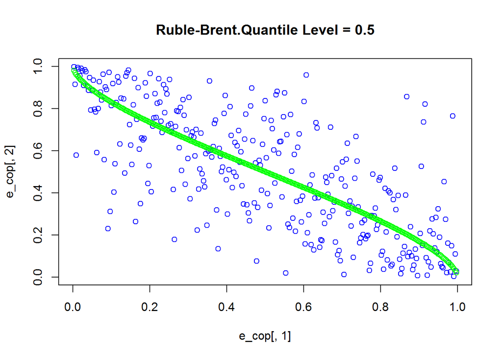

```r
quantileLevel <- function(numCopula,copula, theta,alpha)
{
  if (numCopula == 1)
  {
#Gaussian
    q <- pnorm(qnorm(alpha) *sqrt(1-theta*theta)  + theta* qnorm(copula[,1]))
  }
  if (numCopula == 2)
  {
    #Student
  }
  if (numCopula == 3)
  {
    #Frank
  }
  if (numCopula == 4)
  {
    #Clayton
  }
  return(q)
}

alpha <- 0.50
copulanum <- 1
parameters <- Gaussian.Copula.fit@copula@parameters
q <- quantileLevel(copulanum,e_cop, parameters,alpha)
quantile.Level <- q

plot(e_cop[,1],e_cop[,2],pch =21,col = "blue",main = "Ruble-Brent.Quantile Level = 0.5")
points(e_cop[,1],quantile.Level,col = "green")
```

Соответствующие графики для копул Student,Frank, и Clayton получите самостоятельно.

Эти картинки особенно полезны при исследовании величины VAR (value ar risk). Часто оценку величины потерь вычисляют для $\alpha = 0.95$. В частности найдем пары значений переменных , для которых вторая переменная больше кванитли уровня $\alpha = 0.95$.

```r
alpha <- 0.95
q <- quantileLevel(copulanum,e_cop, parameters,alpha)
quantile.Level <- q

plot(e_cop[,1],e_cop[,2],pch =20,col = "blue",main = "Ruble-Brent. VAR Level = 0.95")
points(e_cop[,1],quantile.Level,col = "green",pch = 20)
(anomalindex <- which(e_cop[,2]>quantile.Level))
```

```
##  [1]  50  72  73  84  99 107 116 140 158 172 185 242 284 290
```

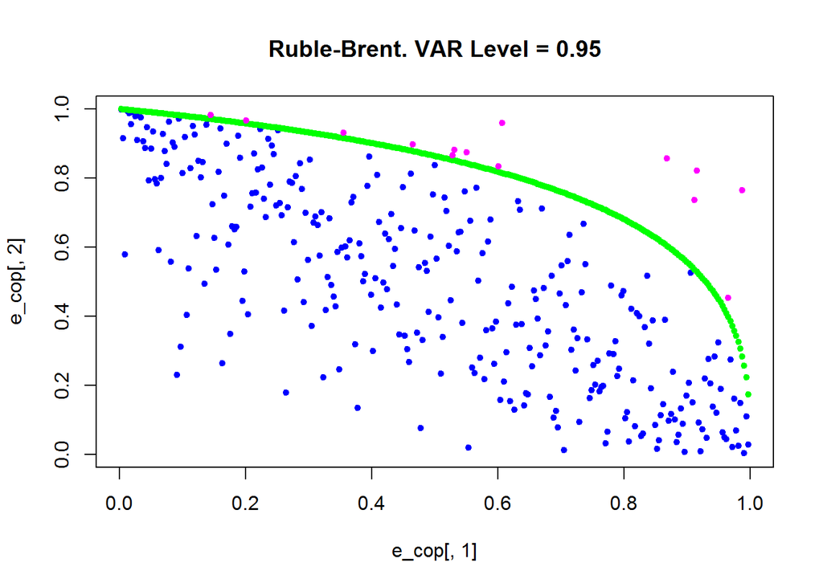

```r
points(e_cop[anomalindex,1],e_cop[anomalindex,2],col = "magenta",pch = 20)
```

На этом графике аномальные пары точек и квантиль заданного уровня избражены на копуле. Теперь нарисуем расположение аномальных пар точек на графике исходных переменных рубль-брент.

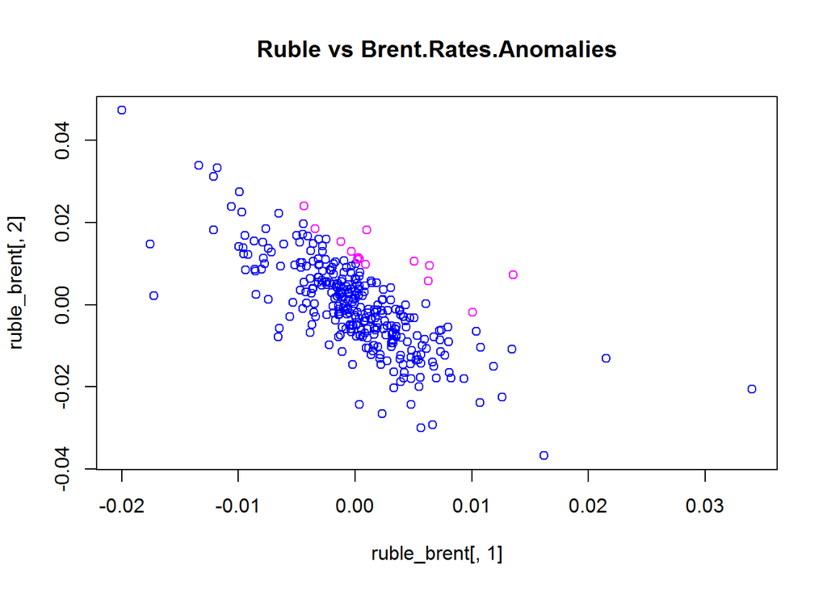

```r
plot(ruble_brent[,1],ruble_brent[,2],pch = 21,col= "blue",main ="Ruble vs Brent.Rates.Anomalies")
points(ruble_brent[anomalindex,1],ruble_brent[anomalindex,2],pch = 21,col= "magenta")
```

```r
anomalies <-cbind(ruble_brent[anomalindex,1],ruble_brent[anomalindex,2])
head(anomalies)
```

```
##              [,1]         [,2]
## [1,] -0.004373511  0.023992003
## [2,]  0.000358858  0.011220196
## [3,]  0.000253146  0.011442441
## [4,] -0.001225371  0.015332198
## [5,]  0.010081011 -0.001777462
## [6,] -0.000306312  0.013001083
```